# MANOVA en DCA

Efecto de 5 tratamientos de fertilización sobre 4 variables de crecimiento

Grupo 4

2026-09-12

# Introducción

Previo al análisis, se verificarán los supuestos de normalidad multivariada, homogeneidad de matrices de varianza-covarianza y correlación entre las variables respuesta; posteriormente, en caso de detectarse diferencias significativas a nivel global, se realizarán comparaciones múltiples por pares (incluyendo la comparación de cada tratamiento frente al control) para identificar entre qué grupos específicos se presentan dichas diferencias.

# Desarrollo

### Paquetes a utilizar

```r
library(tidyverse)
library(readxl)
library(mvnormtest)
library(heplots)
library(psych)
library(emmeans)
```

### Lectura de Datos

```r
datos <- read_excel("datos_manova_dca.xlsx")
datos$Tratamiento <- as.factor(datos$Tratamiento)

str(datos)
```

```
## tibble [75 × 6] (S3: tbl_df/tbl/data.frame)
##  $ Unidad_Exp    : num [1:75] 1 2 3 4 5 6 7 8 9 10 ...
##  $ Tratamiento   : Factor w/ 5 levels "T1","T2","T3",..: 1 1 1 1 1 1 1 1 1 1 ...
##  $ Altura_cm     : num [1:75] 29.3 34.6 26 34.3 32.6 25.9 31.5 31.5 30.2 31.3 ...
##  $ Peso_seco_g   : num [1:75] 6.17 8.56 5.32 9.43 11.89 ...
##  $ N_hojas       : num [1:75] 10 13 10 14 13 12 13 13 14 11 ...
##  $ Clorofila_SPAD: num [1:75] 30.4 36.7 31.2 33.3 37.6 36.9 36.4 35 31.2 37.6 ...
```

```r
head(datos, 10)
```

```
## # A tibble: 10 × 6
##    Unidad_Exp Tratamiento Altura_cm Peso_seco_g N_hojas Clorofila_SPAD
##         <dbl> <fct>           <dbl>       <dbl>   <dbl>          <dbl>
##  1          1 T1               29.3        6.17      10           30.4
##  2          2 T1               34.6        8.56      13           36.7
##  3          3 T1               26          5.32      10           31.2
##  4          4 T1               34.3        9.43      14           33.3
##  5          5 T1               32.6       11.9       13           37.6
##  6          6 T1               25.9        6.89      12           36.9
##  7          7 T1               31.5        8.89      13           36.4
##  8          8 T1               31.5        8.36      13           35
##  9          9 T1               30.2        8.3       14           31.2
## 10         10 T1               31.3        7         11           37.6
```

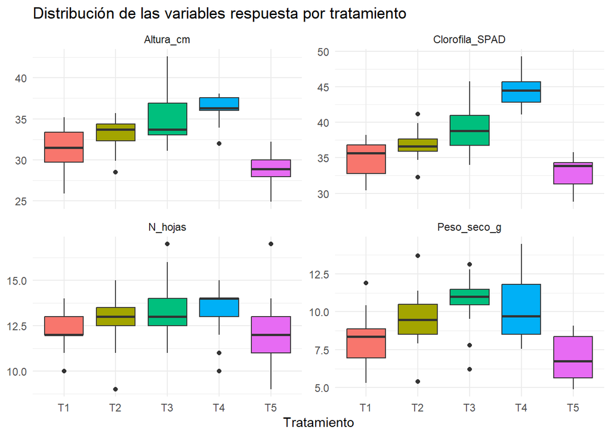

```r
datos %>%
  pivot_longer(cols = c(Altura_cm, Peso_seco_g, N_hojas, Clorofila_SPAD),
               names_to = "Variable", values_to = "Valor") %>%
  ggplot(aes(x = Tratamiento, y = Valor, fill = Tratamiento)) +
  geom_boxplot(show.legend = FALSE) +
  facet_wrap(~ Variable, scales = "free_y") +
  theme_minimal() +
  labs(title = "Distribución de las variables respuesta por tratamiento",
       x = "Tratamiento", y = NULL)
```

# I. Supuesto de variables dependientes correlacionadas

Antes de ajustar un modelo MANOVA es indispensable comprobar que las variables respuesta no son independientes entre sí, ya que si no existiera correlación entre ellas no habría ninguna ventaja en analizarlas de forma conjunta y bastaría con realizar un ANOVA independiente para cada una. Para ello se verifica que las variables respuesta estén correlacionadas entre sí mediante el test de esfericidad de Bartlett, el cual contrasta si la matriz de correlaciones poblacional es igual a la matriz identidad (es decir, si todas las correlaciones entre pares de variables son simultáneamente nulas).

Sean $Y_1, Y_2, Y_3, Y_4$ las cuatro variables respuesta (Altura_cm, Peso_seco_g, N_hojas y Clorofila_SPAD, respectivamente) y $\rho_{v v'}$ el coeficiente de correlación poblacional entre las variables $Y_v$ y $Y_{v'}$, con $v, v' = 1, 2, 3, 4$ los índices que identifican a cada una de dichas variables. Las hipótesis del test quedan planteadas como:

$$H_0: \rho_{v v'} = 0 \quad \text{para todo } v \neq v', \quad
v,v' = 1,2,3,4$$

$$H_1: \rho_{v v'} \neq 0 \quad \text{para algún par } v \neq v'$$

Es decir, bajo $H_0$ ninguna de las cuatro variables de crecimiento estaría correlacionada con las demás, mientras que bajo $H_1$ existiría al menos un par de variables (por ejemplo, altura de planta y peso seco) que sí estarían asociadas entre sí.

```r
vars_respuesta <- datos %>%
  dplyr::select(,-c(1,2))

cortest.bartlett(cor(vars_respuesta), n = nrow(vars_respuesta))
```

```
## $chisq
## [1] 108.1488
##
## $p.value
## [1] 4.975115e-21
##
## $df
## [1] 6
```

**Interpretación:** La prueba de esfericidad de Bartlett nos indica que a un 0.05 de nivel de significancia existe suficiente evidencia estadística para rechazar la hipótesis nula. Por lo que podemos asegurar que la matriz de correlaciones es significativamente diferente de la identidad. Razón por lo cual tiene sentido aplicar un MANOVA en lugar de varios ANOVA.

# II. Supuesto de normalidad multivariada

El MANOVA asume que, dentro de cada grupo de tratamiento, el vector de variables respuesta sigue una distribución normal multivariada. Este supuesto es necesario para que los estadísticos de contraste (Pillai, Wilks, Hotelling-Lawley y Roy) tengan las propiedades distribucionales bajo las cuales se calculan sus valores p. Se evalúa la normalidad multivariada dentro de cada tratamiento mediante el test de Shapiro-Wilk multivariado (`mshapiro.test`), aplicado de forma independiente a las observaciones de cada uno de los cinco tratamientos.

Sea $\mathbf{X}_t = (X_{t1}, X_{t2}, X_{t3}, X_{t4})'$ el vector de variables respuesta observado en el $t$-ésimo tratamiento, con $t = 1, 2, 3, 4, 5$ (correspondiente a T1, T2, T3, T4 y T5). Para cada tratamiento $t$ se contrasta:

$$H_0: \mathbf{X}_t \sim N_p(\boldsymbol{\mu}_t, \boldsymbol{\Sigma}_t)$$

$$H_1: \mathbf{X}_t \nsim N_p(\boldsymbol{\mu}_t, \boldsymbol{\Sigma}_t)$$

Donde $\mathbf{X}_t$ es el vector de variables respuesta (Altura_cm, Peso_seco_g, N_hojas, Clorofila_SPAD) para el tratamiento $t$, $p = 4$ es el número de variables, $\boldsymbol{\mu}_t$ es el vector de medias poblacional de ese tratamiento y $\boldsymbol{\Sigma}_t$ es su matriz de varianza-covarianza. La prueba se repite para cada uno de los cinco tratamientos ($t = 1, \dots, 5$), por lo que en total se obtienen cinco contrastes independientes de normalidad multivariada.

```r
trat1 <- datos %>% filter(Tratamiento == "T1") %>%
  dplyr::select(,-c(1,2))
trat2 <- datos %>% filter(Tratamiento == "T2") %>%
  dplyr::select(,-c(1,2))
trat3 <- datos %>% filter(Tratamiento == "T3") %>%
  dplyr::select(,-c(1,2))
trat4 <- datos %>% filter(Tratamiento == "T4") %>%
  dplyr::select(,-c(1,2))
trat5 <- datos %>% filter(Tratamiento == "T5") %>%
  dplyr::select(,-c(1,2))
```

```r
mshapiro.test(t(trat1))
```

```
##
##  Shapiro-Wilk normality test
##
## data:  Z
## W = 0.85766, p-value = 0.02233
```

```r
mshapiro.test(t(trat2))
```

```
##
##  Shapiro-Wilk normality test
##
## data:  Z
## W = 0.81385, p-value = 0.005567
```

```r
mshapiro.test(t(trat3))
```

```
##
##  Shapiro-Wilk normality test
##
## data:  Z
## W = 0.87021, p-value = 0.03398
```

```r
mshapiro.test(t(trat4))
```

```
##
##  Shapiro-Wilk normality test
##
## data:  Z
## W = 0.86873, p-value = 0.03233
```

```r
mshapiro.test(t(trat5))
```

```
##
##  Shapiro-Wilk normality test
##
## data:  Z
## W = 0.76403, p-value = 0.001317
```

Todas las pruebas rechazan la normalidad multivariada de las variables respuesta para cada uno de los 5 tratamientos. Se procederá a verificar el cumplimiento del supuesto de homogeneidad para tomar una decisión.

**Interpretación:** El incumplimiento de la normalidad multivariada no invalida automáticamente el uso del MANOVA: dado que los tamaños de muestra por grupo son moderados (15 repeticiones por tratamiento) y relativamente balanceados, los estadísticos multivariados —en particular el de Pillai— suelen mantener un buen desempeño incluso ante desviaciones de la normalidad, siempre que se cumpla el supuesto de homogeneidad de matrices de varianza-covarianza. Por ello, antes de decidir cómo proceder, es necesario evaluar dicho supuesto en la siguiente sección.

# III. Supuesto de homogeneidad de matrices varianza-covarianza

Además de la normalidad multivariada, el MANOVA requiere que la estructura de varianzas y covarianzas entre las variables respuesta sea la misma en los cinco tratamientos, de modo que las diferencias detectadas entre grupos puedan atribuirse a diferencias en las medias y no a diferencias en la variabilidad o en el patrón de asociación entre variables. Este supuesto se evalúa mediante el test M de Box, que contrasta la igualdad de las matrices de varianza-covarianza entre los grupos de tratamiento.

Sea $\boldsymbol{\Sigma}_t$ la matriz de varianza-covarianza poblacional (de dimensión $4 \times 4$, una fila/columna por cada variable respuesta) correspondiente al $t$-ésimo tratamiento, con $t = 1, 2, 3, 4, 5$ identificando a T1, T2, T3, T4 y T5 respectivamente. Las hipótesis se plantean como:

$$H_0: \boldsymbol{\Sigma}_1 = \boldsymbol{\Sigma}_2 =
\boldsymbol{\Sigma}_3 = \boldsymbol{\Sigma}_4 = \boldsymbol{\Sigma}_5$$

$$H_1: \boldsymbol{\Sigma}_t \neq \boldsymbol{\Sigma}_{t'} \quad
\text{para algún par } t \neq t', \quad t,t' = 1,2,3,4,5$$

Es decir, bajo $H_0$ los cinco tratamientos comparten una única estructura de varianzas y covarianzas entre las variables de crecimiento, mientras que bajo $H_1$ al menos dos tratamientos (identificados por los índices $t$ y $t'$) presentarían matrices de varianza-covarianza distintas entre sí.

```r
boxM_res <- heplots::boxM(
  cbind(Altura_cm, Peso_seco_g, N_hojas, Clorofila_SPAD) ~ Tratamiento,
  data = datos
)
boxM_res
```

```
##
##  Box's M-test for Homogeneity of Covariance Matrices
##
## data:  datos
## Chi-Sq (approx.) = 45.8964, df = 40, p-value = 0.241
```

```r
summary(boxM_res)
```

```
##
##  Box's M-test for Homogeneity of Covariance Matrices
##
## data:  datos
##
## Chi-Sq (approx.) =  45.89636
## df:   40
## p-value: 0.24
##
## log of Covariance determinants:
##     T1     T2     T3     T4     T5 pooled
## 4.1309 4.1991 6.0880 4.3468 4.4859 5.3976
##
## Eigenvalues:
##         T1      T2      T3      T4     T5 pooled
## 1 11.05059 6.91712 14.9544 7.49533 6.9246 9.0198
## 2  6.16404 4.56677  7.9700 6.59277 4.7023 5.1805
## 3  2.07503 2.60911  2.3695 1.97227 2.6164 2.8870
## 4  0.44028 0.80835  1.5600 0.79244 1.0419 1.6374
##
## Statistics based on eigenvalues:
##                 T1       T2        T3       T4       T5    pooled
## product   62.23108 66.62353 440.55575 77.23048 88.76114 220.88366
## sum       19.72994 14.90135  26.85388 16.85280 15.28519  18.72463
## precision  0.33268  0.50406   0.79656  0.48684  0.58855   0.79302
## max       11.05059  6.91712  14.95443  7.49533  6.92464   9.01977
```

El test M de Box nos indica que a un nivel de significancia de 0.05 no existe evidencia estadística suficiente para rechaza la homogeneidad de las matrices varianza-covarianza de cada uno de los tratamientos.

**Interpretación:** Gracias al cumplimiento de este supuesto, podemos proseguir con la aplicación del MANOVA, pues este, y los estadísticos a probar, son robustos ante el incumplimento de la normalidad multivariada. Y en conjunto con el cumplimento de la homogeneidad nos darán estimaciones razonablemente válidas.

En resumen, aunque el supuesto de normalidad multivariada no se cumplió de forma estricta en ninguno de los cinco tratamientos, el cumplimiento de la homogeneidad de las matrices de varianza-covarianza —sumado al tamaño de muestra balanceado (15 unidades experimentales por tratamiento)— respalda que los resultados del MANOVA sean confiables.

# IV. MANOVA en DCA

Una vez verificados los supuestos necesarios, se ajusta el modelo MANOVA bajo un Diseño Completamente al Azar, donde el único factor de clasificación es el tratamiento de fertilización y las cuatro variables respuesta se modelan de manera conjunta como un vector.

```r
modelo <- manova(
  cbind(Altura_cm, Peso_seco_g, N_hojas, Clorofila_SPAD) ~ Tratamiento,
  data = datos
)
```

# Matrices SCPC del factor, residual y total. Bondad de ajuste

En el contexto multivariado, la descomposición de la variabilidad total ya no se realiza mediante sumas de cuadrados escalares como en un ANOVA univariado, sino mediante matrices de sumas de cuadrados y productos cruzados (SCPC). La matriz $\mathbf{T}$ (total) se descompone en una matriz asociada al factor tratamiento, $\mathbf{H}$ (denotada `Fm` ), y una matriz residual o de error, $\mathbf{E}$ (denotada `W`, de “within” o “dentro de grupos”), de modo que $\mathbf{T} = \mathbf{H} + \mathbf{E}$. Capturando así tanto la variabilidad individual como la covariabilidad conjunta.

```r
Matrices <- summary(modelo)$SS
Fm <- Matrices$Tratamiento
W  <- Matrices$Residuals
Tm <- Fm + W

Fm
```

```
##                Altura_cm Peso_seco_g   N_hojas Clorofila_SPAD
## Altura_cm       528.9427   267.24607 106.86000       751.7927
## Peso_seco_g     267.2461   143.73829  54.85467       345.9504
## N_hojas         106.8600    54.85467  22.26667       153.2200
## Clorofila_SPAD  751.7927   345.95037 153.22000      1240.3461
```

```r
W
```

```
##                Altura_cm Peso_seco_g   N_hojas Clorofila_SPAD
## Altura_cm      420.11733   129.90713  40.34000       88.64133
## Peso_seco_g    129.90713   234.94429  83.43733       90.19780
## N_hojas         40.34000    83.43733 189.73333       90.62000
## Clorofila_SPAD  88.64133    90.19780  90.62000      465.92933
```

```r
Tm
```

```
##                Altura_cm Peso_seco_g N_hojas Clorofila_SPAD
## Altura_cm       949.0600    397.1532 147.200       840.4340
## Peso_seco_g     397.1532    378.6826 138.292       436.1482
## N_hojas         147.2000    138.2920 212.000       243.8400
## Clorofila_SPAD  840.4340    436.1482 243.840      1706.2755
```

Cálculo del $\eta^2$ para identificar la variabilidad de los tratamientos.

```r
eta2 <- 1 - det(W) / det(Tm)
eta2
```

```
## [1] 0.8161539
```

**Interpretación:** Podemos decir que una proporción del 0.8161 o un 81.61% de la variabilidad de las variables respuesta pueden ser explicadas por la aplicación de los tratamientos. Siendo este un porcentaje bastante satisfactorio para determinar la influencia de los tratamientos en las decisiones que se tomarán.

Este $\eta^2$ multivariado, calculado como $1 - \frac{|\mathbf{E}|}{|\mathbf{T}|}$, es el análogo multivariado del coeficiente de determinación $R^2$ de un modelo univariado. Un valor tan alto como 0.8161 sugiere que el factor tratamiento tiene una capacidad explicativa muy fuerte sobre el conjunto de las cuatro variables de crecimiento.

# V. Pruebas de hipótesis del modelo

Con el modelo ya ajustado, se contrasta la hipótesis central del MANOVA: si los vectores de medias de las cuatro variables respuesta son iguales entre los cinco tratamientos, o si al menos uno de ellos difiere del resto. Sea $\boldsymbol{\mu}_t = (\mu_{t1}, \mu_{t2}, \mu_{t3}, \mu_{t4})'$ el vector de medias poblacional de las variables respuesta (Altura_cm, Peso_seco_g, N_hojas, Clorofila_SPAD) para el $t$-ésimo tratamiento, con $t = 1, 2, 3, 4, 5$. Las hipótesis se plantean como:

$$H_0: \boldsymbol{\mu}_1 = \boldsymbol{\mu}_2 = \boldsymbol{\mu}_3 =
\boldsymbol{\mu}_4 = \boldsymbol{\mu}_5$$

$$H_1: \boldsymbol{\mu}_t \neq \boldsymbol{\mu}_{t'} \quad \text{para
algún par } t \neq t', \quad t,t' = 1,2,3,4,5$$

Bajo $H_0$ los cinco tratamientos producirían, en promedio, el mismo efecto conjunto sobre las cuatro variables de crecimiento; bajo $H_1$ existiría al menos un par de tratamientos $t$ y $t'$ cuyos vectores de medias serían distintos.

```r
summary(modelo, test = "Pillai")
```

```
##             Df  Pillai approx F num Df den Df    Pr(>F)
## Tratamiento  4 0.98002   5.6789     16    280 1.295e-10 ***
## Residuals   70
## ---
## Signif. codes:  0 '***' 0.001 '**' 0.01 '*' 0.05 '.' 0.1 ' ' 1
```

```r
summary(modelo, test = "Wilks")
```

```
##             Df   Wilks approx F num Df den Df    Pr(>F)
## Tratamiento  4 0.18385   9.5074     16 205.33 < 2.2e-16 ***
## Residuals   70
## ---
## Signif. codes:  0 '***' 0.001 '**' 0.01 '*' 0.05 '.' 0.1 ' ' 1
```

```r
summary(modelo, test = "Hotelling-Lawley")
```

```
##             Df Hotelling-Lawley approx F num Df den Df    Pr(>F)
## Tratamiento  4           3.5542    14.55     16    262 < 2.2e-16 ***
## Residuals   70
## ---
## Signif. codes:  0 '***' 0.001 '**' 0.01 '*' 0.05 '.' 0.1 ' ' 1
```

```r
summary(modelo, test = "Roy")
```

```
##             Df    Roy approx F num Df den Df    Pr(>F)
## Tratamiento  4 3.2874    57.53      4     70 < 2.2e-16 ***
## Residuals   70
## ---
## Signif. codes:  0 '***' 0.001 '**' 0.01 '*' 0.05 '.' 0.1 ' ' 1
```

A un nivel de significancia del 0.05, cada una de las pruebas estadísticas rechazan la hipótesis nula. Por lo tanto, podemos asegurar que existe al menos un tratamiento cuya influencia sobre las variables respuesta difiere sobre el resto de los vectores media.

**Interpretación:** Es importante notar que este resultado global únicamente confirma la existencia de al menos una diferencia significativa en algún lugar del conjunto de tratamientos, pero no indica todavía cuáles tratamientos específicos difieren entre sí ni en qué variables particulares se manifiesta dicha diferencia.

# VI. ANOVAs univariados por variable respuesta

Habiendo rechazado la hipótesis multivariada global, resulta natural preguntarse en cuáles de las cuatro variables respuesta se concentra el efecto del tratamiento. Para ello se descompone el modelo MANOVA en cuatro ANOVA univariados, uno por cada variable, manteniendo la misma estructura del factor Tratamiento.

```r
summary.aov(modelo)
```

```
##  Response Altura_cm :
##             Df Sum Sq Mean Sq F value    Pr(>F)
## Tratamiento  4 528.94 132.236  22.033 8.406e-12 ***
## Residuals   70 420.12   6.002
## ---
## Signif. codes:  0 '***' 0.001 '**' 0.01 '*' 0.05 '.' 0.1 ' ' 1
##
##  Response Peso_seco_g :
##             Df Sum Sq Mean Sq F value    Pr(>F)
## Tratamiento  4 143.74  35.935  10.707 7.925e-07 ***
## Residuals   70 234.94   3.356
## ---
## Signif. codes:  0 '***' 0.001 '**' 0.01 '*' 0.05 '.' 0.1 ' ' 1
##
##  Response N_hojas :
##             Df  Sum Sq Mean Sq F value Pr(>F)
## Tratamiento  4  22.267  5.5667  2.0538 0.0962 .
## Residuals   70 189.733  2.7105
## ---
## Signif. codes:  0 '***' 0.001 '**' 0.01 '*' 0.05 '.' 0.1 ' ' 1
##
##  Response Clorofila_SPAD :
##             Df  Sum Sq Mean Sq F value    Pr(>F)
## Tratamiento  4 1240.35 310.087  46.587 < 2.2e-16 ***
## Residuals   70  465.93   6.656
## ---
## Signif. codes:  0 '***' 0.001 '**' 0.01 '*' 0.05 '.' 0.1 ' ' 1
```

**Interpretación:** Los ANOVA individuales nos indican de que las variables “Altura_cm”, “Peso_seco_g” y “Clorofila_SPAD” fueron significativas para rechazar la hipótesis nula de las 4 pruebas previas. Sin embargo la variable N_hojas no fue significativa para rechazar la hipótesis nula.

# VII. Comparaciones por pares

Para identificar específicamente entre qué tratamientos se presentan las diferencias detectadas por el MANOVA, se reajusta el modelo como una regresión lineal multivariada (`lm`) equivalente y se obtienen las medias marginales estimadas (`emmeans`) de cada tratamiento para las cuatro variables respuesta en conjunto. Estas medias marginales servirán de base para las comparaciones múltiples que se presentan a continuación.

```r
fit <- lm(cbind(Altura_cm, Peso_seco_g, N_hojas, Clorofila_SPAD) ~ Tratamiento,
          data = datos)

emm <- emmeans(fit, ~ Tratamiento | rep.meas)
emm
```

```
## rep.meas = Altura_cm:
##  Tratamiento emmean    SE df lower.CL upper.CL
##  T1           31.30 0.633 70    30.04    32.56
##  T2           33.13 0.633 70    31.87    34.39
##  T3           35.01 0.633 70    33.75    36.27
##  T4           36.21 0.633 70    34.95    37.47
##  T5           28.75 0.633 70    27.49    30.01
##
## rep.meas = Peso_seco_g:
##  Tratamiento emmean    SE df lower.CL upper.CL
##  T1            8.17 0.473 70     7.23     9.11
##  T2            9.51 0.473 70     8.57    10.46
##  T3           10.70 0.473 70     9.76    11.65
##  T4           10.32 0.473 70     9.38    11.26
##  T5            6.98 0.473 70     6.03     7.92
##
## rep.meas = N_hojas:
##  Tratamiento emmean    SE df lower.CL upper.CL
##  T1           12.33 0.425 70    11.49    13.18
##  T2           12.80 0.425 70    11.95    13.65
##  T3           13.33 0.425 70    12.49    14.18
##  T4           13.47 0.425 70    12.62    14.31
##  T5           12.07 0.425 70    11.22    12.91
##
## rep.meas = Clorofila_SPAD:
##  Tratamiento emmean    SE df lower.CL upper.CL
##  T1           34.92 0.666 70    33.59    36.25
##  T2           36.87 0.666 70    35.54    38.20
##  T3           39.14 0.666 70    37.81    40.47
##  T4           44.82 0.666 70    43.49    46.15
##  T5           33.06 0.666 70    31.73    34.39
##
## Confidence level used: 0.95
```

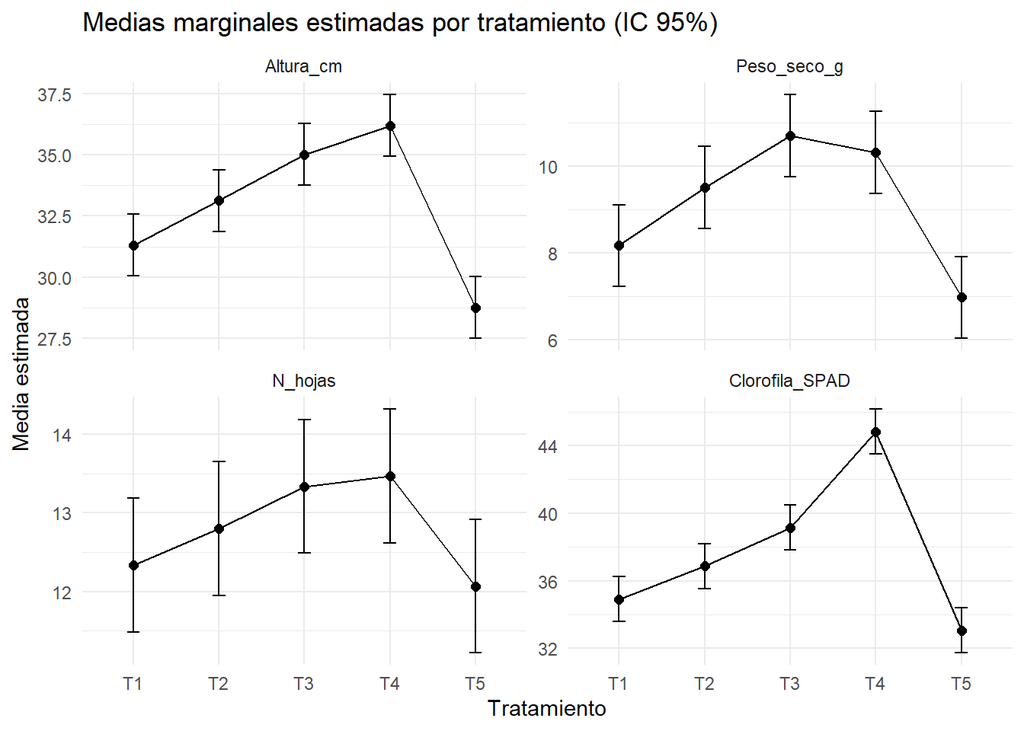

```r
as.data.frame(emm) %>%
  ggplot(aes(x = Tratamiento, y = emmean, group = 1)) +
  geom_point(size = 2) +
  geom_line() +
  geom_errorbar(aes(ymin = lower.CL, ymax = upper.CL), width = 0.15) +
  facet_wrap(~ rep.meas, scales = "free_y") +
  theme_minimal() +
  labs(title = "Medias marginales estimadas por tratamiento (IC 95%)",
       x = "Tratamiento", y = "Media estimada")
```

## VIII. Comparación general por Pares

Una vez confirmado que existen diferencias globales entre tratamientos, se procede a realizar todas las comparaciones posibles entre pares de tratamientos ($\binom{5}{2} = 10$ contrastes en total).

Sean $t$ y $t'$ dos tratamientos distintos cualesquiera del conjunto $\{T1, T2, T3, T4, T5\}$, con $t, t' = 1,2,\dots,5$ y $t \neq t'$. Para cada par $(t, t')$ se contrasta:

$$H_0:
\begin{pmatrix} \mu_{Altura,t} \\ \mu_{Peso,t} \\ \mu_{Nhojas,t} \\
\mu_{Clorofila,t} \end{pmatrix}
=
\begin{pmatrix} \mu_{Altura,t'} \\ \mu_{Peso,t'} \\
\mu_{Nhojas,t'} \\ \mu_{Clorofila,t'} \end{pmatrix}$$

$$H_1:
\begin{pmatrix} \mu_{Altura,t} \\ \mu_{Peso,t} \\ \mu_{Nhojas,t} \\
\mu_{Clorofila,t} \end{pmatrix}
\neq
\begin{pmatrix} \mu_{Altura,t'} \\ \mu_{Peso,t'} \\
\mu_{Nhojas,t'} \\ \mu_{Clorofila,t'} \end{pmatrix}$$

$$\text{para todo par } t \neq t', \quad t,t' = 1,2,\dots,5$$

Es decir, para cada uno de los diez pares de tratamientos posibles se evalúa si el vector completo de medias (altura, peso seco, número de hojas y clorofila) de un tratamiento $t$ es igual al del tratamiento $t'$, o si difiere en al menos una de sus cuatro componentes.

```r
mvcontrast(emm, method = "pairwise", mult.name = "rep.meas", adjust = "bonferroni")
```

```
##  contrast T.square df1 df2 F.ratio p.value
##  T1 - T2     8.056   4  67   1.928  1.0000
##  T1 - T3    33.651   4  67   8.052  0.0002
##  T1 - T4   125.444   4  67  30.017 <0.0001
##  T1 - T5    10.621   4  67   2.541  0.4767
##  T2 - T3     8.895   4  67   2.129  0.8684
##  T2 - T4    79.408   4  67  19.001 <0.0001
##  T2 - T5    36.267   4  67   8.678  0.0001
##  T3 - T4    43.688   4  67  10.454 <0.0001
##  T3 - T5    80.287   4  67  19.211 <0.0001
##  T4 - T5   195.671   4  67  46.821 <0.0001
##
## P value adjustment: bonferroni
```

## Comparación de cada Tratamiento frente al Control (T1)

Además de las comparaciones exhaustivas entre todos los pares de tratamientos, tiene particular interés agronómico comparar cada tratamiento de fertilización directamente contra el grupo control (T1), pues esto permite determinar cuáles tratamientos generan realmente una mejora respecto a no aplicar fertilización.

Sea $t = 2, 3, 4, 5$ el índice de cada uno de los tratamientos de fertilización (T2, T3, T4 y T5) y $t = 1$ el índice fijo correspondiente al tratamiento control (T1). Para cada tratamiento $t \in \{2,3,4,5\}$ se contrasta:

$$H_0:
\begin{pmatrix} \mu_{Altura,t} \\ \mu_{Peso,t} \\ \mu_{Nhojas,t} \\
\mu_{Clorofila,t} \end{pmatrix}
=
\begin{pmatrix} \mu_{Altura,1} \\ \mu_{Peso,1} \\ \mu_{Nhojas,1} \\
\mu_{Clorofila,1} \end{pmatrix}$$

$$H_1:
\begin{pmatrix} \mu_{Altura,t} \\ \mu_{Peso,t} \\ \mu_{Nhojas,t} \\
\mu_{Clorofila,t} \end{pmatrix}
\neq
\begin{pmatrix} \mu_{Altura,1} \\ \mu_{Peso,1} \\ \mu_{Nhojas,1} \\
\mu_{Clorofila,1} \end{pmatrix}$$

$$\text{para cada } t = 2,3,4,5$$

```r
mvcontrast(emm, method = "trt.vs.ctrl1", mult.name = "rep.meas",
           ref = "T1", adjust = "bonferroni")
```

```
##  contrast T.square df1 df2 F.ratio p.value
##  T2 - T1     8.056   4  67   1.928  0.4637
##  T3 - T1    33.651   4  67   8.052 <0.0001
##  T4 - T1   125.444   4  67  30.017 <0.0001
##  T5 - T1    10.621   4  67   2.541  0.1907
##
## P value adjustment: bonferroni
```

# Conclusiones